# **Data Science con `R`**

Instituto de Estadística PUCV - Magister en Estadística

Dae-Jin Lee < dlee@bcamath.org >

Presentación ``Data Visualization in Social Sciences’’

**Chambers et al. (1983)**

*``No existe una herramienta estadística tan poderosa como un gráfico bien escogido’’*

# Visualización de datos

- Una de las principales razones por las que los analistas de datos recurren a `R` es por su gran capacidad gráfica.
- Esta sección proporciona una introducción completa sobre cómo representar datos mediante el sistema de gráficos por defecto de `R`.
- Las posibilidades gráficas de `R` son enormes (*casi infinitas*).
- Muchas librerías disponen de representaciones gráficas muy útiles para la representación de datos y de modelos.
- Veamos a continuación algunos ejemplos.

## Objetivos de este tema

- Conocer las capacidades gráficas básicas de `R`
- Aprender a personalizar gráficos, y conocer los tipos de gráficos más complejos desde el punto de vista estadístico.
- Trabajar con datos reales y realizar análisis descriptivos y gráficos.
- Realizar gráficos con librerías como `ggplot2`
- Guardar gráficos en los diferentes formatos para utilizarlos posteriormente en presentaciones, informes etc …

## Preliminares

- Instalar las siguientes librerías de `R

```r
install.packages("DAAG")
install.packages("calibrate")
install.packages("corrplot")
install.packages("gplots")
install.packages("HSAUR2")
install.packages("sp")
install.packages("maps")
install.packages("maptools")
install.packages("RColorBrewer")
install.packages("RgoogleMaps")
```

## Datos cuantitativos

Vamos a comenzar con el conjunto de datos en el `data.frame`: `pressure` (ver `?pressure`)

```r
?pressure
head(pressure)
```

| temperature | pressure |
| --- | --- |
| 0 | 0.0002 |
| 20 | 0.0012 |
| 40 | 0.0060 |
| 60 | 0.0300 |
| 80 | 0.0900 |
| 100 | 0.2700 |

Función `plot`

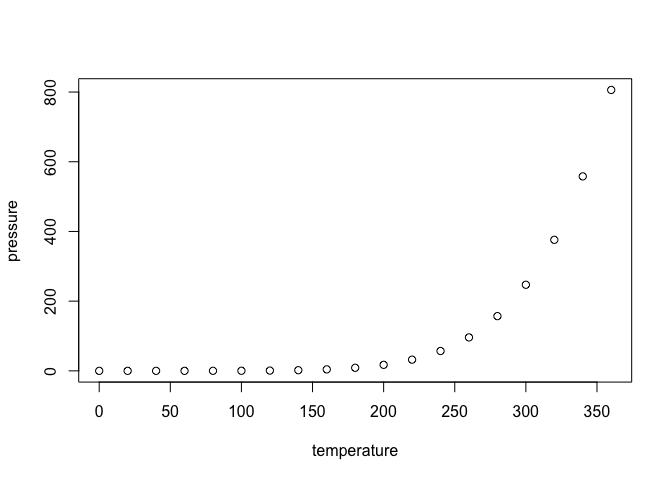

```r
plot(pressure)
```

Función `text`

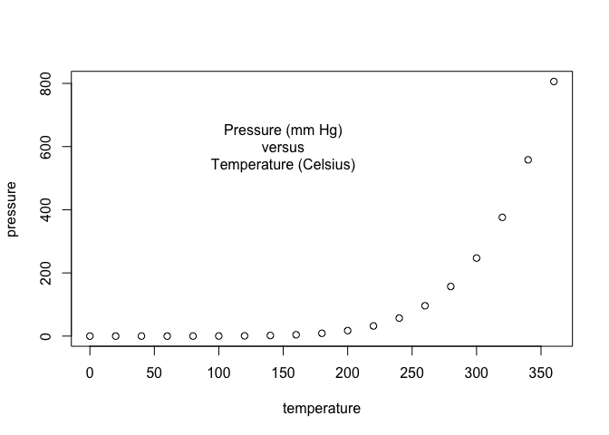

```r
plot(pressure)
text(150, 600,
     "Pressure (mm Hg)\nversus\nTemperature (Celsius)")
```

La opción `cex` permite aumentar el tamaño de la fuente

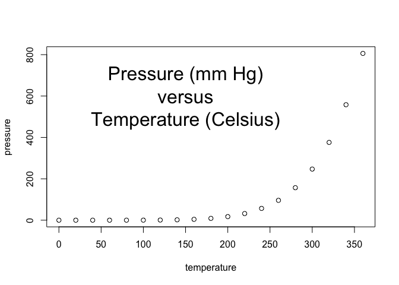

```r
plot(pressure)
text(150, 600, cex = 2,
     "Pressure (mm Hg)\nversus\nTemperature (Celsius)")
```

La opción `log = "y"`, representa la variable `y` en escala logarítmica.

`xlab` e `ylab` permite añadir texto a los ejes y `main` el título del gráfico.

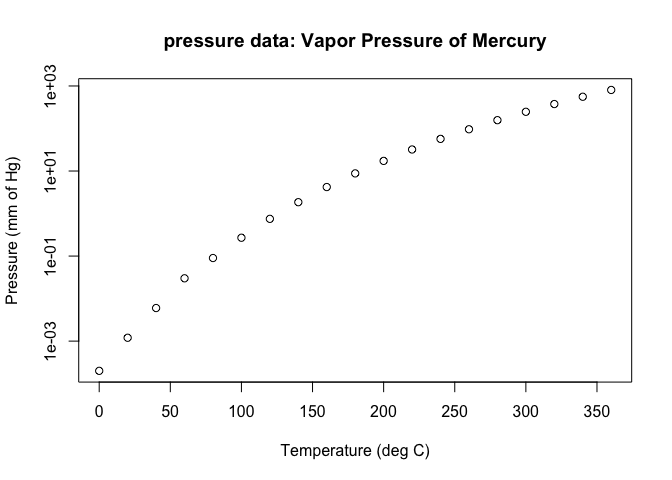

```r
plot(pressure, xlab = "Temperature (deg C)",  log = "y",
     ylab = "Pressure (mm of Hg)",
     main = "pressure data: Vapor Pressure of Mercury")
```

## Datos `mtcars`

`?mtcars`

```r
head(mtcars)
```

|  | mpg | cyl | disp | hp | drat | wt | qsec | vs | am | gear | carb |
| --- | --- | --- | --- | --- | --- | --- | --- | --- | --- | --- | --- |
| Mazda RX4 | 21.0 | 6 | 160 | 110 | 3.90 | 2.620 | 16.46 | 0 | 1 | 4 | 4 |
| Mazda RX4 Wag | 21.0 | 6 | 160 | 110 | 3.90 | 2.875 | 17.02 | 0 | 1 | 4 | 4 |
| Datsun 710 | 22.8 | 4 | 108 | 93 | 3.85 | 2.320 | 18.61 | 1 | 1 | 4 | 1 |
| Hornet 4 Drive | 21.4 | 6 | 258 | 110 | 3.08 | 3.215 | 19.44 | 1 | 0 | 3 | 1 |
| Hornet Sportabout | 18.7 | 8 | 360 | 175 | 3.15 | 3.440 | 17.02 | 0 | 0 | 3 | 2 |
| Valiant | 18.1 | 6 | 225 | 105 | 2.76 | 3.460 | 20.22 | 1 | 0 | 3 | 1 |

```r
names(mtcars)
```

```
##  [1] "mpg"  "cyl"  "disp" "hp"   "drat" "wt"   "qsec" "vs"   "am"   "gear"
## [11] "carb"
```

### Scatterplot ó gráfico X-Y

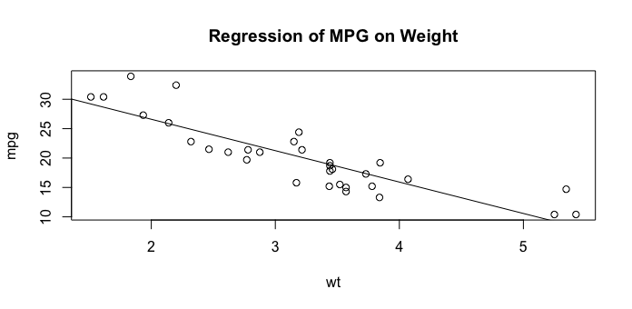

```r
attach(mtcars)
plot(wt, mpg);
abline(lm(mpg~wt)); title("Regression of MPG on Weight")
```

### Scatterplot matrix (ver`?pairs`)

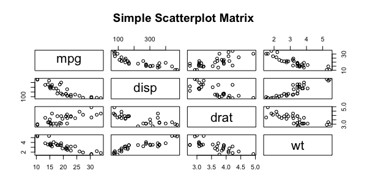

```r
pairs(~mpg+disp+drat+wt,data=mtcars,
       main="Simple Scatterplot Matrix")
```

### Diagrama de barras (ver `?barplot`)

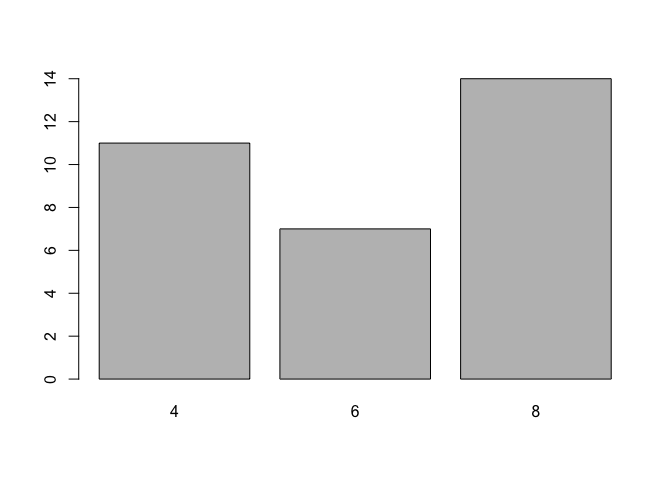

```r
tab <- table(mtcars[,c("cyl")]) # convertir a tabla
barplot(tab)
```

### Piechart o diagrama de tarta (ver `?pie`)

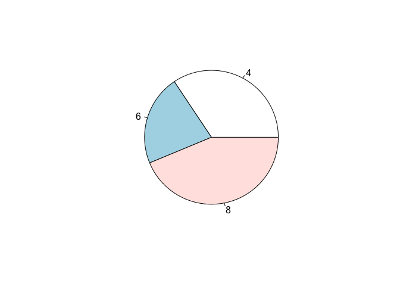

```r
pie(tab)
```

### Datos `VADeaths`

- El `data.frame` `VADeaths` contiene las tasas de mortalidad por cada 1000 habitantes en Virginia (EEUU) en 1940
- Las tasas de mortalidad se miden cada 1000 habitantes por año. Se encuentran clasificadas por grupo de edad (filas) y grupo de población (columnas).
- Los grupos de edad son: 50-54, 55-59, 60-64, 65-69, 70-74 y los grupos de población: `Rural/Male`, `Rural/Female`, `Urban/Male` and `Urban/Female`.

```r
data(VADeaths)
VADeaths
```

```
##       Rural Male Rural Female Urban Male Urban Female
## 50-54       11.7          8.7       15.4          8.4
## 55-59       18.1         11.7       24.3         13.6
## 60-64       26.9         20.3       37.0         19.3
## 65-69       41.0         30.9       54.6         35.1
## 70-74       66.0         54.3       71.1         50.0
```

- Calcula la media por grupo de edad y la media por grupo de población (**Pista:** puedes usar la función `apply`)

Función `apply`

- **Resultado**

```r
apply(VADeaths,1,mean)
```

```
##  50-54  55-59  60-64  65-69  70-74
## 11.050 16.925 25.875 40.400 60.350
```

```r
apply(VADeaths,2,mean)
```

```
##   Rural Male Rural Female   Urban Male Urban Female
##        32.74        25.18        40.48        25.28
```

### Data `rainforest`

```r
library(DAAG)
head(rainforest)
```

|  | dbh | wood | bark | root | rootsk | branch | species |
| --- | --- | --- | --- | --- | --- | --- | --- |
| 27 | 6 | NA | NA | 6 | 0.3 | NA | Acacia mabellae |
| 61 | 23 | 353 | NA | 135 | 13.0 | 35 | Acacia mabellae |
| 62 | 20 | 208 | NA | NA | NA | 41 | Acacia mabellae |
| 63 | 23 | 445 | NA | NA | NA | 50 | Acacia mabellae |
| 65 | 24 | 590 | NA | NA | NA | NA | Acacia mabellae |
| 80 | 5 | 14 | NA | 2 | 2.4 | NA | Acacia mabellae |

- Crear una tabla de conteos para cada `species` y realiza un gráfico descriptivo.
- **Resultado:**

```r
table(rainforest$species)
```

```
##
## Acacia mabellae      C. fraseri  Acmena smithii   B. myrtifolia
##              16              12              26              11
```

### Diagrama de barras

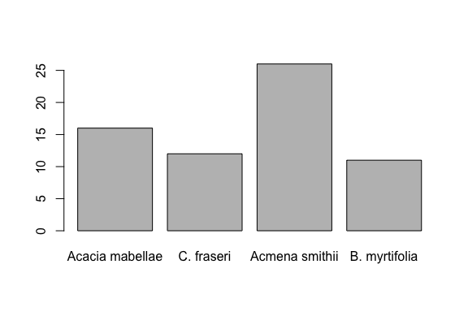

```r
barplot(table(rainforest$species))
```

`?subset`

- El `data.frame` `Acmena` está creado a partir de `rainforest` mediante la función `subset`.

```r
Acmena <- subset(rainforest, species == "Acmena smithii")
```

- Vamos a realizar un gráfico que relacione la biomasa de la madera (`wood`) y el diámetro a la altura del pecho (`dbh`).
- Utiliza también la escala logarítmica.

`par` y `mfrow`

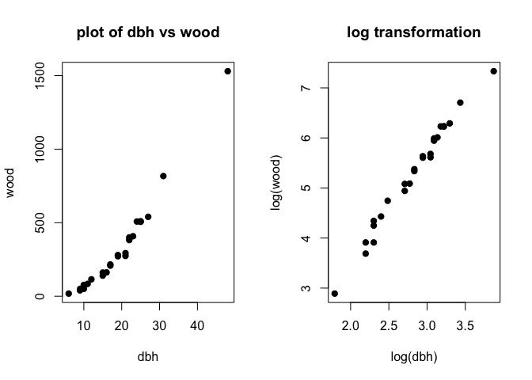

```r
par(mfrow=c(1,2))
plot(wood~dbh,data=Acmena,pch=19, main="plot of dbh vs wood")
plot(log(wood)~log(dbh),data=Acmena,pch=19,main="log transformation")
```

### Histograma

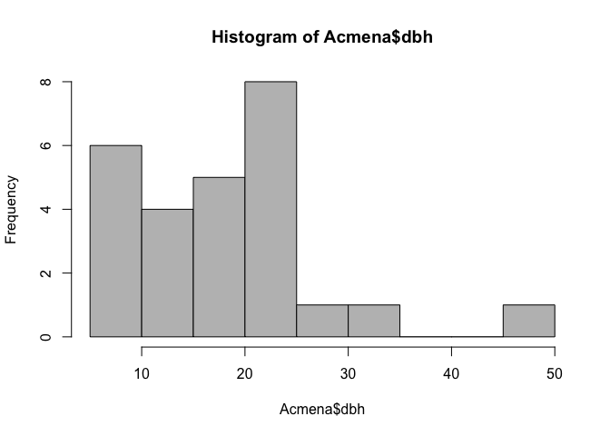

```r
hist(Acmena$dbh,col="grey")
```

Más sobre gráficos XY

- Datos `mammals`

```r
library(MASS)
data("mammals")
?mammals
head(mammals)
```

|  | body | brain |
| --- | --- | --- |
| Arctic fox | 3.385 | 44.5 |
| Owl monkey | 0.480 | 15.5 |
| Mountain beaver | 1.350 | 8.1 |
| Cow | 465.000 | 423.0 |
| Grey wolf | 36.330 | 119.5 |
| Goat | 27.660 | 115.0 |

```r
attach(mammals)
species <- row.names(mammals)
x <- body
y <- brain
```

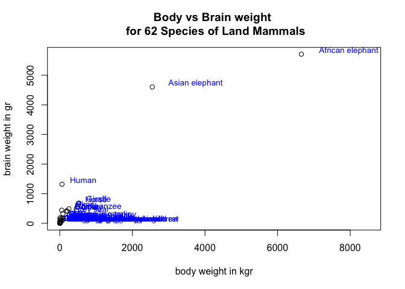

```r
library(calibrate)
# scatterplot
plot(x,y, xlab = "body weight in kgr", ylab = "brain weight in gr",
     main="Body vs Brain weight \n for 62 Species of Land Mammals",xlim=c(0,8500))
textxy(x,y,labs=species,col = "blue",cex=0.85)
```

`identify`

Identificar un punto en el scatterplot

```r
identify(x,y,species)
```

En escala logarítmica

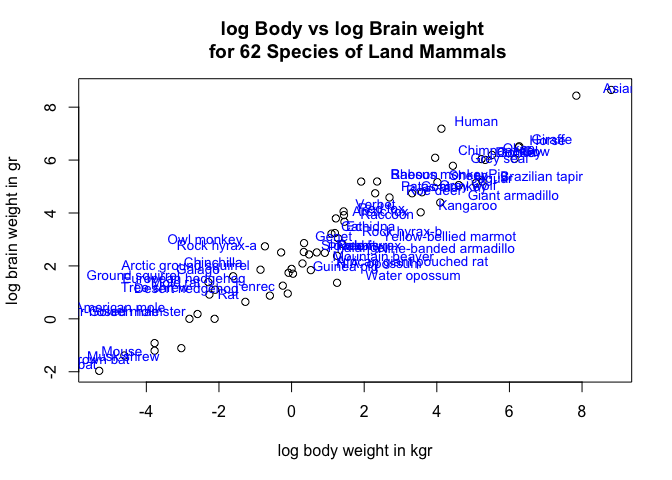

```r
plot(log(x),log(y), xlab = "log body weight in kgr", ylab = "log brain weight in gr",
     main="log Body vs log Brain weight \n for 62 Species of Land Mammals")
textxy(log(x),log(y),labs=species,col = "blue",cex=0.85)
```

## Matrices de correlación

- La función `corrplot` de la librería `corrplot` permite visualizar una matriz de correlaciones calculada mediante la función `cor`
- Vamos a generar unos datos de manera aleatoria.
- Mediante `set.seed(1234)` generaremos números aleatorios a partir de la misma semilla.

```r
set.seed(1234)
uData <- rnorm(20)
vData <- rnorm(20,mean=5)
wData <- uData + 2*vData + rnorm(20,sd=0.5)
xData <- -2*uData+rnorm(20,sd=0.1)
yData <-  3*vData+rnorm(20,sd=2.5)
d <- data.frame(u=uData,v=vData,w=wData,x=xData,y=yData)
```

`pairs`

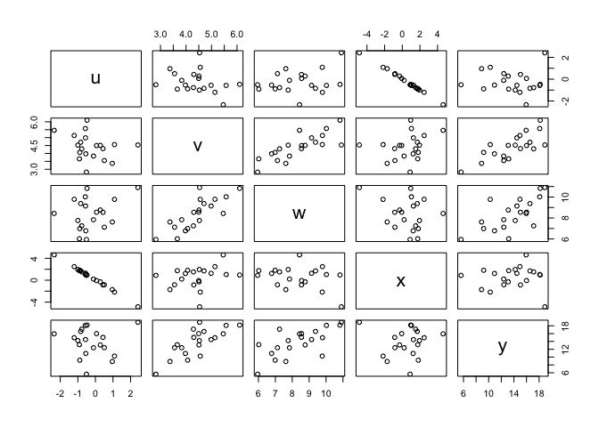

```r
pairs(d)
```

`corrplot`

```r
library(corrplot)
M <- cor(d)
M
```

```
##             u          v          w           x           y
## u  1.00000000 -0.2765719  0.2927511 -0.99868977 -0.04024035
## v -0.27657193  1.0000000  0.7924159  0.27353287  0.75719956
## w  0.29275113  0.7924159  1.0000000 -0.29680269  0.67192135
## x -0.99868977  0.2735329 -0.2968027  1.00000000  0.03090972
## y -0.04024035  0.7571996  0.6719213  0.03090972  1.00000000
```

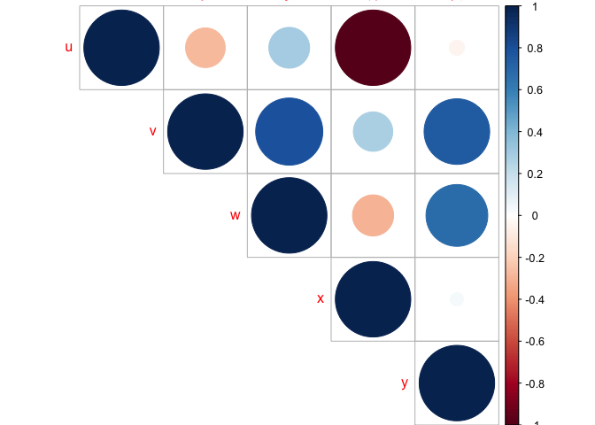

```r
corrplot(M, method="circle",type="upper")
```

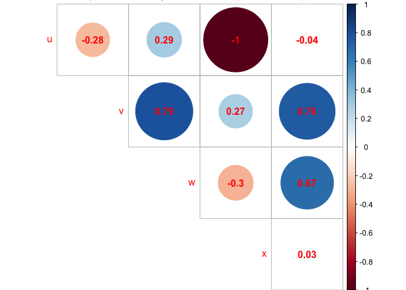

```r
corrplot(M, method="circle",type="upper", diag = FALSE,
         addCoef.col = "red")
```

## `UCBAdmissions`

- El conjunto de datos de `R`, `UCBAdmissions`contiene los datos agregadps de los solicitantes a universidad de Berkeley a los seis departamentos más grandes en 1973 clasificados por sexo y admisión.

```r
data("UCBAdmissions")
?UCBAdmissions
apply(UCBAdmissions, c(2,1), sum)
```

```
##         Admit
## Gender   Admitted Rejected
##   Male       1198     1493
##   Female      557     1278
```

```r
prop.table(apply(UCBAdmissions, c(2,1), sum))
```

```
##         Admit
## Gender    Admitted  Rejected
##   Male   0.2646929 0.3298719
##   Female 0.1230667 0.2823685
```

```r
ftable(UCBAdmissions)
```

```
##                 Dept   A   B   C   D   E   F
## Admit    Gender
## Admitted Male        512 353 120 138  53  22
##          Female       89  17 202 131  94  24
## Rejected Male        313 207 205 279 138 351
##          Female       19   8 391 244 299 317
```

Con `ftable` podemos presentar la información con mayor claridad

```r
ftable(round(prop.table(UCBAdmissions), 3),
       row.vars="Dept", col.vars = c("Gender", "Admit"))
```

```
##      Gender     Male            Female
##      Admit  Admitted Rejected Admitted Rejected
## Dept
## A              0.113    0.069    0.020    0.004
## B              0.078    0.046    0.004    0.002
## C              0.027    0.045    0.045    0.086
## D              0.030    0.062    0.029    0.054
## E              0.012    0.030    0.021    0.066
## F              0.005    0.078    0.005    0.070
```

Resulta más intereseante mostrar la información por género `Gender` y `Dept` combinados (dimensiones 2 y 3 del array). Nótese que las tasas de admisión por `male` y `female` son más o menos similares en todos los departamentos, excepto en “A”, donde las tasas de las mujeres es mayor.

```r
ftable(round(prop.table(UCBAdmissions, c(2,3)), 2),
       row.vars="Dept", col.vars = c("Gender", "Admit"))
```

```
##      Gender     Male            Female
##      Admit  Admitted Rejected Admitted Rejected
## Dept
## A               0.62     0.38     0.82     0.18
## B               0.63     0.37     0.68     0.32
## C               0.37     0.63     0.34     0.66
## D               0.33     0.67     0.35     0.65
## E               0.28     0.72     0.24     0.76
## F               0.06     0.94     0.07     0.93
```

**Datos de admisiones agregados por Sexo/Departamento**

```r
apply(UCBAdmissions, c(1, 2), sum)
```

```
##           Gender
## Admit      Male Female
##   Admitted 1198    557
##   Rejected 1493   1278
```

```r
apply(UCBAdmissions, c(1, 2), sum)
```

```
##           Gender
## Admit      Male Female
##   Admitted 1198    557
##   Rejected 1493   1278
```

### Representación gráfica datos categóricos (`spineplot`)

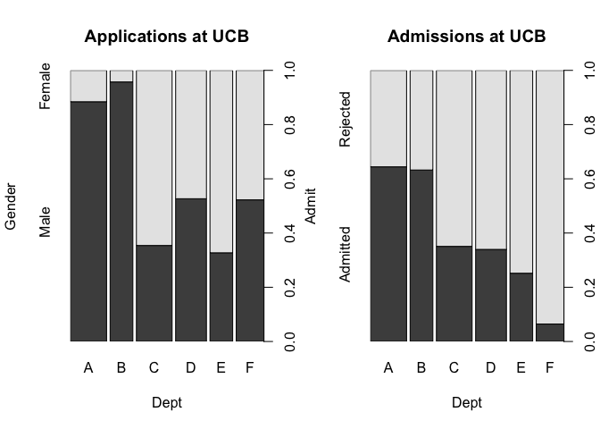

```r
par(mfrow=c(1,2))
spineplot(margin.table(UCBAdmissions, c(3, 2)),
           main = "Applications at UCB")
spineplot(margin.table(UCBAdmissions, c(3, 1)),
           main = "Admissions at UCB")
```

### Paradoja de Simpson

- Estos datos ilustran la denominada *paradoja de Simpson*.
- Este hecho ha sido analizado como un posible caso de discriminación por sexo en las tasas de admisión en Berkeley.
- De los 2691 hombres que solicitaron se admitidos, 1198 (44.5%) fueron admitidos, comparado con las 1835 mujeres de las cuales tan sólo 557 (30.4%) fueron admitidas.
- Se podría por tanto concluir que los hombres tienes tasas de admisi?n mayores que las mujeres.
- [**Wikipedia:** *Gender Bias UC Berkeley*](https://en.wikipedia.org/wiki/Simpson%27s_paradox#UC_Berkeley_gender_bias).
- Ver animación en [*link*](http://vudlab.com/simpsons/)

### Datos `faithful`

- Consideremos los datos del geyse Old Faithful en el parque nacional de Yellowstone, EEUU.

```r
head(faithful)
```

| eruptions | waiting |
| --- | --- |
| 3.600 | 79 |
| 1.800 | 54 |
| 3.333 | 74 |
| 2.283 | 62 |
| 4.533 | 85 |
| 2.883 | 55 |

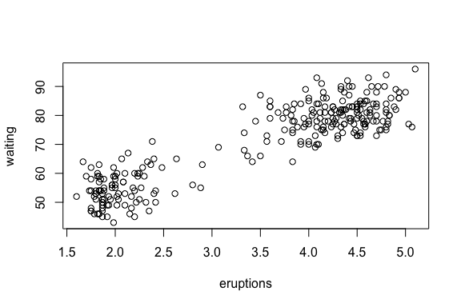

```r
plot(faithful)
```

### Histograma (`hist`)

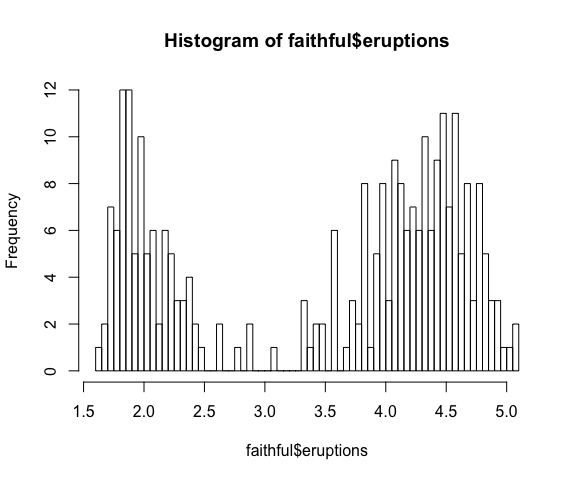

```r
hist(faithful$eruptions,50)
```

### Estimación de densidades

- **Estimación de densidad** construye una estimación dada una distribucion de probabilidad para una muestra dada.

```r
library(graphics)
d <- density(faithful$eruptions)
d
```

```
##
## Call:
##  density.default(x = faithful$eruptions)
##
## Data: faithful$eruptions (272 obs.); Bandwidth 'bw' = 0.3348
##
##        x                y
##  Min.   :0.5957   Min.   :0.0002262
##  1st Qu.:1.9728   1st Qu.:0.0514171
##  Median :3.3500   Median :0.1447010
##  Mean   :3.3500   Mean   :0.1813462
##  3rd Qu.:4.7272   3rd Qu.:0.3086071
##  Max.   :6.1043   Max.   :0.4842095
```

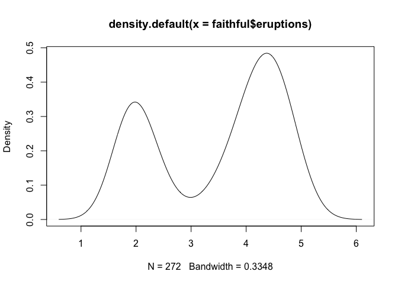

```r
plot(d)
```

### Histograma y Densidad

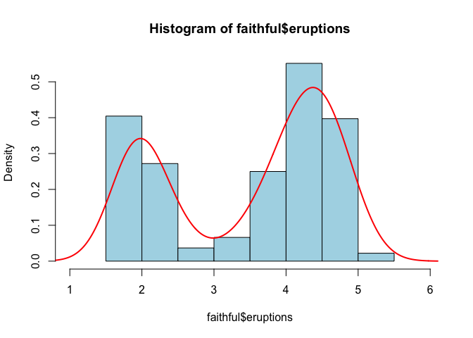

```r
hist(faithful$eruptions,freq=FALSE, col = "lightblue", xlim = c(1,6))
lines(d, col = "red", lwd = 2)
```

### Histograma bivariante

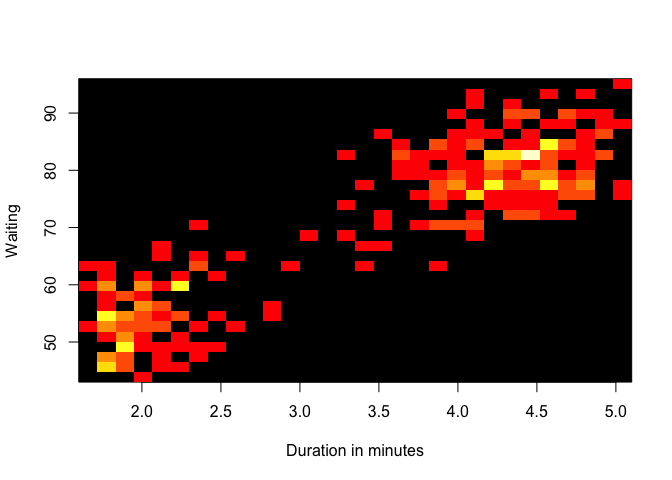

```r
library(gplots)
h2 <- hist2d(faithful, nbins=30,xlab="Duration in minutes",ylab="Waiting")
```

```r
h2
```

```
##
## ----------------------------
## 2-D Histogram Object
## ----------------------------
##
## Call: hist2d(x = faithful, nbins = 30, xlab = "Duration in minutes",
##     ylab = "Waiting")
##
## Number of data points:  272
## Number of grid bins:  30 x 30
## X range: ( 1.6 , 5.1 )
## Y range: ( 43 , 96 )
```

```r
class(h2)
```

```
## [1] "hist2d"
```

```r
names(h2)
```

```
## [1] "counts"   "x.breaks" "y.breaks" "x"        "y"        "nobs"
## [7] "call"
```

### Estimación de densidades bivariantes (`kde2d`)

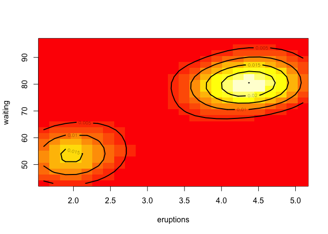

```r
Dens2d<-kde2d(faithful$eruptions,faithful$waiting)
image(Dens2d,xlab="eruptions",ylab="waiting")
contour(Dens2d,add=TRUE,col="black",lwd=2,nlevels=5)
```

### `persp`

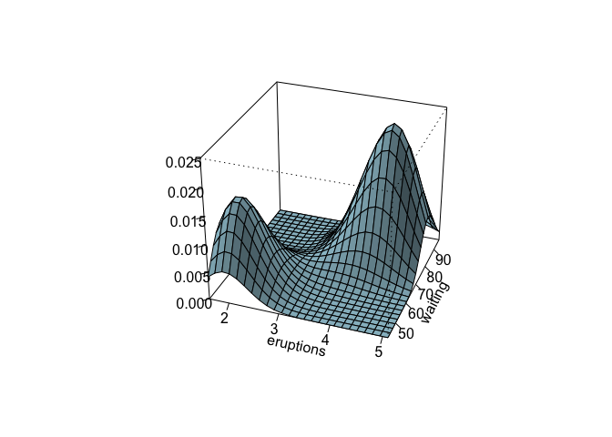

```r
persp(Dens2d,phi=30,theta=20,d=5,xlab="eruptions",ylab="waiting",zlab="",shade=.2,col="lightblue",expand=.85,ticktype = "detailed")
```

# Ejemplo: Forbes 2000 (ranking de las empresas líderes en 2004)

- La lista Forbes 2000 para el año 2004 recogida por la revista Forbes. Esta lista está disponible originalmente en `www.forbes.com`

```r
library("HSAUR2")
data("Forbes2000")
dim(Forbes2000)
```

```
## [1] 2000    8
```

```r
names(Forbes2000)
```

```
## [1] "rank"        "name"        "country"     "category"    "sales"
## [6] "profits"     "assets"      "marketvalue"
```

```r
library(knitr)
kable(head(Forbes2000))
```

| rank | name | country | category | sales | profits | assets | marketvalue |
| --- | --- | --- | --- | --- | --- | --- | --- |
| 1 | Citigroup | United States | Banking | 94.71 | 17.85 | 1264.03 | 255.30 |
| 2 | General Electric | United States | Conglomerates | 134.19 | 15.59 | 626.93 | 328.54 |
| 3 | American Intl Group | United States | Insurance | 76.66 | 6.46 | 647.66 | 194.87 |
| 4 | ExxonMobil | United States | Oil & gas operations | 222.88 | 20.96 | 166.99 | 277.02 |
| 5 | BP | United Kingdom | Oil & gas operations | 232.57 | 10.27 | 177.57 | 173.54 |
| 6 | Bank of America | United States | Banking | 49.01 | 10.81 | 736.45 | 117.55 |

Los datos consisten en 2000 observaciones sobre las 8 variables siguientes.

- `rank`: el ranking de la empresa.
- `name`: el nombre de la empresa.
- `country`: un factor que determina el país en el que está situada la empresa.
- `category`: un factor que describe los productos que produce la empresa.
- `sales`: el importe de las ventas de la empresa en miles de millones de dólares.
- `profits`: los beneficios de la empresa en miles de millones de dólares.
- `assets`: los activos de la empresa en miles de millones de dólares.
- `marketvalue`: el valor de mercado de la empresa en miles de millones de dólares.

```r
str(Forbes2000)
```

```
## 'data.frame':    2000 obs. of  8 variables:
##  $ rank       : int  1 2 3 4 5 6 7 8 9 10 ...
##  $ name       : chr  "Citigroup" "General Electric" "American Intl Group" "ExxonMobil" ...
##  $ country    : Factor w/ 61 levels "Africa","Australia",..: 60 60 60 60 56 60 56 28 60 60 ...
##  $ category   : Factor w/ 27 levels "Aerospace & defense",..: 2 6 16 19 19 2 2 8 9 20 ...
##  $ sales      : num  94.7 134.2 76.7 222.9 232.6 ...
##  $ profits    : num  17.85 15.59 6.46 20.96 10.27 ...
##  $ assets     : num  1264 627 648 167 178 ...
##  $ marketvalue: num  255 329 195 277 174 ...
```

```r
nlevels(Forbes2000[,"country"])
```

```
## [1] 61
```

- Cuáles son éstos países?

```r
levels(Forbes2000[,"country"])
```

```
##  [1] "Africa"                       "Australia"
##  [3] "Australia/ United Kingdom"    "Austria"
##  [5] "Bahamas"                      "Belgium"
##  [7] "Bermuda"                      "Brazil"
##  [9] "Canada"                       "Cayman Islands"
## [11] "Chile"                        "China"
## [13] "Czech Republic"               "Denmark"
## [15] "Finland"                      "France"
## [17] "France/ United Kingdom"       "Germany"
## [19] "Greece"                       "Hong Kong/China"
## [21] "Hungary"                      "India"
## [23] "Indonesia"                    "Ireland"
## [25] "Islands"                      "Israel"
## [27] "Italy"                        "Japan"
## [29] "Jordan"                       "Kong/China"
```

[output cut: 16 more lines]

- Cuáles en el top 20?

```r
top20 <- droplevels(subset(Forbes2000,rank<=20))
levels(top20[,"country"])
```

```
## [1] "France"                      "Japan"
## [3] "Netherlands"                 "Netherlands/ United Kingdom"
## [5] "Switzerland"                 "United Kingdom"
## [7] "United States"
```

- As a simple summary statistic, the frequencies of the levels of such a factor variable can be found from

```r
table(top20[,"country"])
```

```
##
##                      France                       Japan
##                           2                           1
##                 Netherlands Netherlands/ United Kingdom
##                           1                           1
##                 Switzerland              United Kingdom
##                           1                           3
##               United States
##                          11
```

- Which type of companies?

```r
levels(Forbes2000[,"category"])
```

```
##  [1] "Aerospace & defense"              "Banking"
##  [3] "Business services & supplies"     "Capital goods"
##  [5] "Chemicals"                        "Conglomerates"
##  [7] "Construction"                     "Consumer durables"
##  [9] "Diversified financials"           "Drugs & biotechnology"
## [11] "Food drink & tobacco"             "Food markets"
## [13] "Health care equipment & services" "Hotels restaurants & leisure"
## [15] "Household & personal products"    "Insurance"
## [17] "Materials"                        "Media"
## [19] "Oil & gas operations"             "Retailing"
## [21] "Semiconductors"                   "Software & services"
## [23] "Technology hardware & equipment"  "Telecommunications services"
## [25] "Trading companies"                "Transportation"
## [27] "Utilities"
```

- How many of each category?

```r
table(Forbes2000[,"category"])
```

```
##
##              Aerospace & defense                          Banking
##                               19                              313
##     Business services & supplies                    Capital goods
##                               70                               53
##                        Chemicals                    Conglomerates
##                               50                               31
##                     Construction                Consumer durables
##                               79                               74
##           Diversified financials            Drugs & biotechnology
##                              158                               45
##             Food drink & tobacco                     Food markets
##                               83                               33
## Health care equipment & services     Hotels restaurants & leisure
##                               65                               37
##    Household & personal products                        Insurance
##                               44                              112
##                        Materials                            Media
##                               97                               61
##             Oil & gas operations                        Retailing
##                               90                               88
##                   Semiconductors              Software & services
##                               26                               31
##  Technology hardware & equipment      Telecommunications services
##                               59                               67
##                Trading companies                   Transportation
##                               25                               80
##                        Utilities
##                              110
```

- A simple summary statistics such as the mean, median, quantiles and range can be found from continuous variables such as `sales`

```r
summary(Forbes2000[,"sales"])
```

```
##    Min. 1st Qu.  Median    Mean 3rd Qu.    Max.
##   0.010   2.018   4.365   9.697   9.548 256.300
```

- Histogramas y boxplots

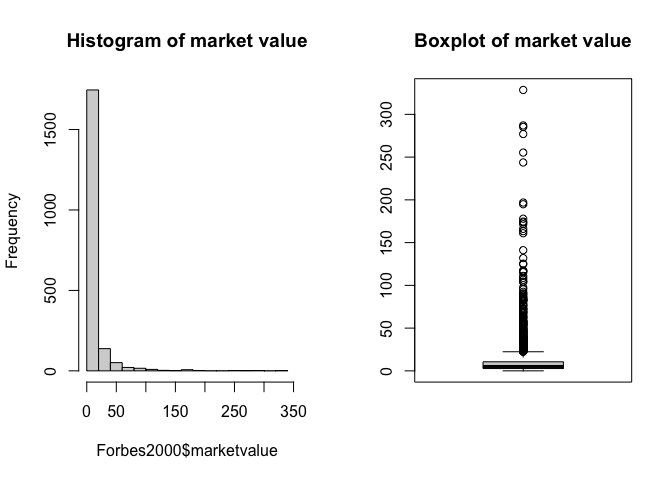

```r
par(mfrow=c(1,2))
hist(Forbes2000$marketvalue, col="lightgrey",main="Histogram of market value")
boxplot(Forbes2000$marketvalue, col="lightgrey",main="Boxplot of market value")
```

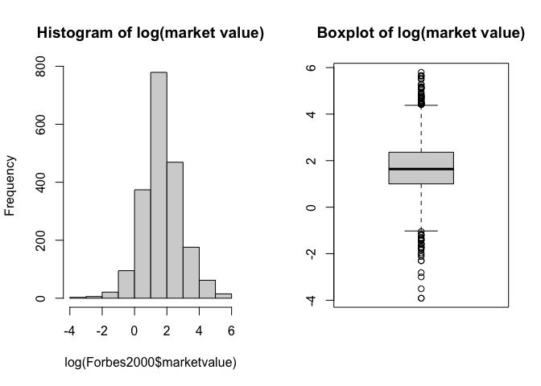

```r
par(mfrow=c(1,2))
hist(log(Forbes2000$marketvalue),col="lightgrey",
     main="Histogram of log(market value)")
boxplot(log(Forbes2000$marketvalue),col="lightgrey",
        main="Boxplot of log(market value)")
```

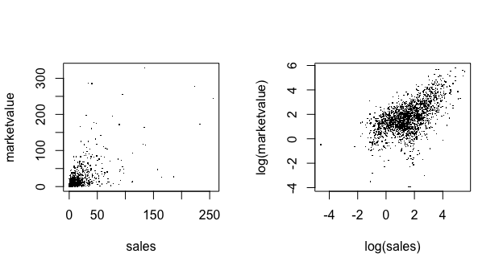

```r
par(mfrow=c(1,2))
plot(marketvalue ~ sales, data = Forbes2000, pch = ".")
plot(log(marketvalue) ~ log(sales), data = Forbes2000, pch = ".")
```

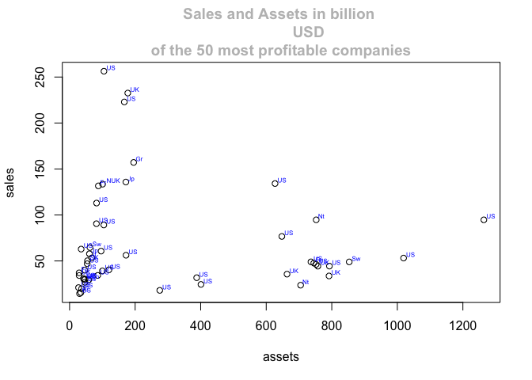

```r
library(calibrate)
profits_all = na.omit(Forbes2000$profits)  # all_profts without No data
order_profits = order(profits_all)     # index of the profitable companies
                                       #    in decreasing order
top_50 = rev(order_profits)[1:50]      # top 50 profitable companies

sales = Forbes2000$sales[top_50]       # sales of the 50 top profitable companies
assets = Forbes2000$assets[top_50]     # assets of the 50 top profitable companies
countries = Forbes2000$country[top_50] # countries where the 50 top profitable
                                       #    companies are found

plot(assets,sales,pch =1)
textxy(assets,sales, abbreviate(countries,2),col = "blue",cex=0.5)  # used to put the
                                                                    # countries where the companies are found
title(main = "Sales and Assets in billion
              USD \n of the 50 most profitable companies ", col.main = "gray")
```

**Gráficos por factor**

Boxplots de los logaritmos del valor de mercado para cuatro países seleccionados, el ancho de las cajas es proporcional a las raíces cuadradas del número de empresas.

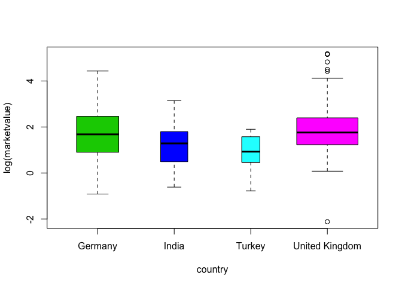

```r
tmp <- subset(Forbes2000,
        country %in% c("United Kingdom", "Germany",
                       "India", "Turkey"))
tmp$country <- tmp$country[,drop = TRUE]
plot(log(marketvalue) ~ country, data = tmp, col = 3:6,
       ylab = "log(marketvalue)", varwidth = TRUE)
```

Scatterplots by country

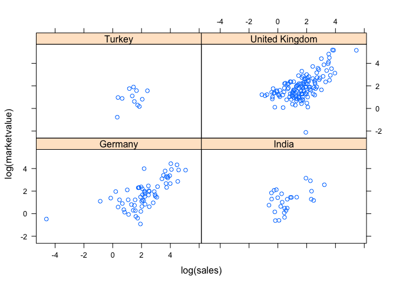

```r
library(lattice)
xyplot(log(marketvalue)~log(sales)|country,data=tmp)
```

**Preguntas**

1. Calcular el beneficio medio de las empresas en EE.UU. y el beneficio medio de las empresas en el Reino Unido, Francia y Alemania.
2. Encuentre todas las empresas alemanas con beneficios negativos.
3. ¿A qué categoría de negocios pertenecen la mayoría de las compañías de las islas Bermuda?
4. Encuentre el valor promedio de las ventas de las compañías en cada país en el conjunto de datos de Forbes, y encuentre el número de compañías en cada país con ganancias superiores a 5 mil millones de dólares estadounidenses.